# MP01 - NETFLIX BY THE NUMBERS

Author

Tova Hirschhorn

Published

October 3, 2025

# I. EXECUTIVE SUMMARY

Mini-Project 01 involved assuming the role of a data analyst supporting the Public Relations team at Netflix by applying foundational data analysis tools and techniques. The primary objective was to extract and analyze public data from Netflix’s TuDum Top 10 list to identify key insights at both global and country-specific levels. These findings were then used to create three targeted press releases, highlighting regional and global content performance.

Key steps in the data analysis process included:

1. Data Acquisition: *Global Top 10* and *Country-wide Top 10* were two separate datasets from Netflix, both imported into R.
2. Data Cleaning: Datasets were cleaned to ensure proper formatting. This included converting placeholder strings, such as “N/A” into proper missing values “NA”, for accurate analysis.
3. Exploratory Data Analysis: Various analytical techniques were used to summarize key findings, identify trends, and evaluate content popularity in global and regional audiences.

This mini-project laid the foundation for effective data analysis by providing practical experience with real-world data. It introduced essential tools for cleaning, transforming, and interpreting data to make informed-strategic decisions for global promotion.

# II. NETFLIX TOP 10: ANALYZING GLOBAL AND COUNTRY-SPECIFIC TRENDS

#### **Q1. NETFLIX’S GLOBAL REACH**

Netflix operates in 94 different countries. Below is a random selection of nations where Netflix streams its content. Its presence across six continents highlights its impressive global reach and influence.

|  | Country |
| --- | --- |
| 1 | Slovenia |
| 2 | Netherlands |
| 3 | Austria |
| 4 | El Salvador |
| 5 | Turkey |
| 6 | Trinidad and Tobago |
| 7 | Latvia |
| 8 | Israel |
| 9 | Paraguay |
| 10 | Kenya |

[output cut: 10 more lines]

#### **Q2. LONGEST-CHARTING NON-ENGLISH FILM ON NETFLIX**

The German anti-war film *All Quiet on the Western Front* was the highest non-English movie on Netflix, spending 276 weeks in the top 10. It was the third film adaptation, based on the 1929 novel by Erich Maria Remarque.

|  | Show Title | Total Number of Weeks |
| --- | --- | --- |
| 1 | All Quiet on the Western Front | 276 |

#### **Q3. FILM WITH GREATEST RUNTIME ON NETFLIX’S GLOBAL TOP 10**

Meanwhile, the longest film to appear on Netflix’s Global Top 10 is *Pushpa 2: The Rule (Reloaded Version)*, with a runtime of 224 minutes. This extended version features almost 23 minutes of additional fight scenes and story elements that viewers can enjoy.

|  | Category | Show Title | Weekly Views | Cumulative Weeks in Top 10 | Runtime in Minutes |
| --- | --- | --- | --- | --- | --- |
| 1 | Films (Non-English) | Pushpa 2: The Rule (Reloaded Version) | 3,600,000 | 2 | 224 |

#### **Q4. TOP PROGRAMS WITH THE HIGHEST GLOBAL VIEWERSHIP**

*KPop Demon Hunters, Society of the Snow, Stranger Things, Squid Game* topped global viewership across all categories, with over 559,100,000, 235,900,000, 2,967,980,000, 5,048,300,000 total hours watched worldwide, respectively!

|  | Category | Show Title | Total Hours Viewed |
| --- | --- | --- | --- |
| 1 | Films (English) | KPop Demon Hunters | 559,100,000 |
| 2 | Films (Non-English) | Society of the Snow | 235,900,000 |
| 3 | TV (English) | Stranger Things | 2,967,980,000 |
| 4 | TV (Non-English) | Squid Game | 5,048,300,000 |

#### **Q5. TV SHOW WITH LONGEST RUN IN A COUNTRY’S TOP 10**

*Money Heist* was the longest-running TV show on Netflix’s Country Top 10 rankings. This popular Spanish crime series resonated strongly with audiences in Pakistan, remaining in the Top 10 for an impressive 127 weeks.

|  | Show Title | Country Name | Total Weeks |
| --- | --- | --- | --- |
| 1 | Money Heist | Pakistan | 127 |

#### **Q6. THE ONE COUNTRY WITH UNDER 200 WEEKS OF DATAY**

Netflix provides over 200 weeks of service history for all. Russia was the one country where it ceased operations back on February 27, 2022, almost immediately following Russia’s full-scale invasion of Ukraine.

|  | Country Name | Weeks Recorded | Date of Last Operation |
| --- | --- | --- | --- |
| 1 | Russia | 35 | February 27, 2022 |

#### **Q7. BREAKING DOWN THE TOTAL WATCH HOURS OF *SQUID GAME***

*Squid Game* has garnered over 5,048,300,000 hours of viewership worldwide across all three seasons. Even with eager anticipation for what happens next, *Squid Games’s* Season 1 still remains the most watched, outpacing its sequels by a significant margin.

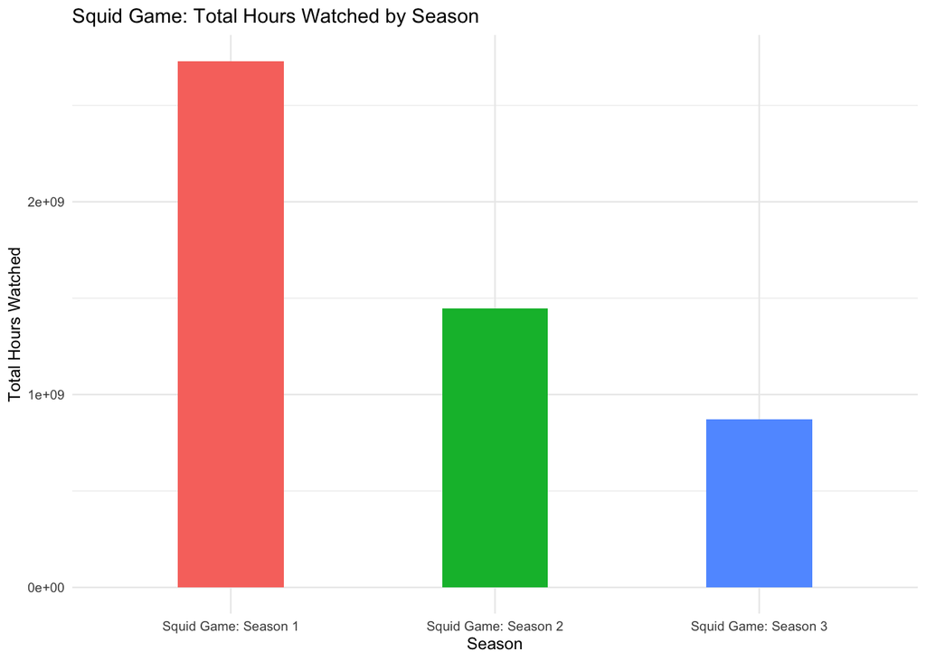

#### **Q8. ESTIMATED 2021 VIEWERSHIP FOR *RED NOTICE***

In 2021, *Red Notice* had 201,390,863 views globally. The success of this action/comedy movie, starring Dwayne Johnson, Gal Gadot, and Ryan Reynolds has led to a sequel that is currently in development, with a release date yet to be announced officially.

|  | Total Estimated Views |
| --- | --- |
| 1 | 201,390,863 |

#### **Q9. RISING TO THE TOP: FILM THAT MADE IT TO #1 AFTER A SLOW DEBUT**

*KPop Demon Hunters* may not have debuted at #1 when it first released, but this animated musical film has captivated audiences of all ages. The success of this movie has kept it in the US Top 10 list for 13 weeks, having finally reached the #1 spot on September 14, 2025.

|  | Show Title | Cumulative Weeks | Week Topped at #1 |
| --- | --- | --- | --- |
| 1 | KPop Demon Hunters | 13 | September 14, 2025 |

#### **Q10. TV SHOW WITH WIDEST GLOBAL TOP 10 DEBUT**

On December 26, 2021, audiences in 94 countries received a holiday gift when *Emily in Paris: Season 2* finally premiered. Fans were eager to learn what would happen between Emily and Gabriel after the Season 1 cliffhanger ending!

|  | Show Title | Season Title | Debut Week | Number of Countries |
| --- | --- | --- | --- | --- |
| 1 | Emily in Paris | Emily in Paris: Season 2 | December 26, 2021 | 94 |

# III. PRESS RELEASES

## Three Years Later…*Stranger Things* Returns to Finish the Story

- Netflix is thrilled to announce the return of *Stranger Things*. Ahead of its highly anticipated series finale, we’re taking a moment to reflect on the show’s global success.
- *Stranger Things* has captivated audiences around the world. It has charted in 93 countries, garnered an impressive 2,967,980,000 hours of viewing across its first four seasons, and spent 20 weeks in Netflix’s Global Top 10.
- Its widespread appeal has made it one of Netflix’s streaming successes and it continues to surpass other platform favorites like *Wednesday* and *Bridgerton* with 2,842,150,000 and 2,279,710,000 of viewership hours, respectively.
- The most recent season of *Stranger Things* brought in its largest viewership yet, drawing in 1,887,310,000 hours. If that momentum is any indication of what to expect, Season 5 will deliver even more mystery, drama, and unforgettable moments.
- *Stranger Things* Season 5 is set to premiere on November 26, 2025.

## Netflix’s Indian Matchmaking: Perfecting the Connection with 1.4 Billion Binge-Lovers

- With over 1.4 billion people, India represents a major growth market for Netflix.
- Hindi-language films and local content have proven highly successful, resonating strongly with Indian audiences through culturally relevant storytelling.
- One standout success, *Saiyaara*, reached the top spot in India and garnered an impressive 21,200,000 total hours of viewership, outpacing the US top-charting *Ice Road: Vengeance*, which earned 14,400,000 total viewing hours.
- India’s chart-topping titles may not have appeared in US rankings, but their outstanding viewership highlights the success of Netflix’s region-focused strategy and the power of culturally tailored programming to drive engagement.
- As Hindi-language content consistently dominate India’s top rankings, the country shows strong long-term growth potential for Netflix.

## Crash Landing into Global Charts: K-Dramas Conquering Audiences Beyond Borders

- Since 2016, Netflix has invested $1 billion in Korean content, with an additional $2.5 billion committed through 2027. This significant investment is clearly paying off, as K-dramas have become a mainstream global phenomenon.
- With 211 unique titles reaching the top spot in Korea’s weekly rankings, K-dramas continue to capture the hearts of its domestic audience. Yet, the love for Korean dramas knows no boundaries.
- Korean shows have charted in the Top 10 in 94 different countries. The world went wild for *Squid Games*, which generated 5,048,300,000 hours of viewership and spent 42 weeks in the global top 10. Though widely considered the most iconic Korean drama to date, other beloved titles have also found major international success. *Extraordinary Attorney Woo*, for example, spent 21 weeks in the top 10 and earned 662,090,000 hours of global watch time.
- The international success of Korean dramas is no accident. They have found a winning formula that resonates with audiences worldwide: diverse genres, relatable themes and characters, high production quality, and emotional authenticity. This combination proves that Korean content has gone beyond regional appeal. It is cementing its place in the global entertainment landscape.